# Resultados Lab 3 - Curso Desembarcando en R

- Recuerden que lo mejor es hablerlo intentado primero, aunque el resultado no sea el “correcto” 👩‍🎓 👨‍🎓
- Hay muchas maneras de hacer lo mismo en R, quizas encuentran una mejor manera a la expuesta acá 😉
- Para ver el resultado de cada ejercicio, apreten el botón `Code`, no el de arriba de todo, sino el de cada ejercicio en particular 📝

## Ejercicios!

1 - Cargar el set de datos “data/bank.csv”.

Los datos historicos reprentan si los clientes hicieron o no un deposito. Indicado en la variable “deposit” (variable a predecir).

```r
library(tidyverse)
library(funModeling)

data_bank=read_delim("../data/bank_2.csv", delim = ";")
```

2 - Hacer una descripcion visual y numérica de las variables numericas (`plot_num`).

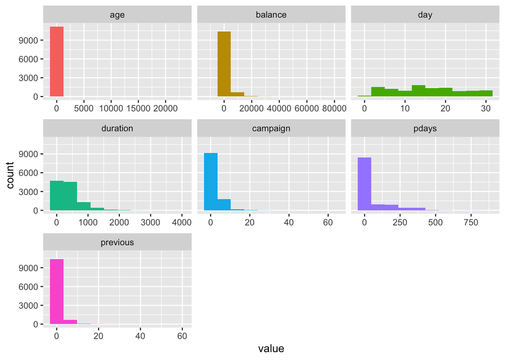

```r
plot_num(data_bank)
```

```r
describe(data_bank)
```

```
## data_bank
##
##  17  Variables      11162  Observations
## ---------------------------------------------------------------------------
## age
##        n  missing distinct     Info     Mean      Gmd      .05      .10
##    11162        0       79    0.999    43.23    17.17       26       28
##      .25      .50      .75      .90      .95
##       32       39       49       58       61
##
## Value          0    50   100   150 22300
## Frequency    452 10537   171     1     1
## Proportion 0.040 0.944 0.015 0.000 0.000
## ---------------------------------------------------------------------------
## job
##        n  missing distinct
##    11162        0       12
##
## admin. (1334, 0.120), blue-collar (1944, 0.174), entrepreneur (328,
## 0.029), housemaid (274, 0.025), management (2566, 0.230), retired (778,
## 0.070), self-employed (405, 0.036), services (923, 0.083), student (360,
## 0.032), technician (1823, 0.163), unemployed (357, 0.032), unknown (70,
## 0.006)
## ---------------------------------------------------------------------------
## marital
##        n  missing distinct
##    11162        0        5
##
## Value      divorced  married   single  singlee singleee
## Frequency      1293     6351     3515        2        1
## Proportion    0.116    0.569    0.315    0.000    0.000
## ---------------------------------------------------------------------------
## education
##        n  missing distinct
##    11162        0        4
##
## Value        primary secondary  tertiary   unknown
## Frequency       1500      5476      3689       497
## Proportion     0.134     0.491     0.330     0.045
## ---------------------------------------------------------------------------
```

[output cut: 93 more lines]

```
##        n  missing distinct
##    11095       67        4
##
## Value      failure   other success unknown
## Frequency     1228     537    1071    8259
## Proportion   0.111   0.048   0.097   0.744
## ---------------------------------------------------------------------------
## deposit
##        n  missing distinct
##    11157        5        2
##
## Value         no   yes
## Frequency   5868  5289
## Proportion 0.526 0.474
## ---------------------------------------------------------------------------
```

```r
profiling_num(data_bank)
```

```
##   variable    mean std_dev variation_coef p_01 p_05 p_25 p_50 p_75 p_95
## 1      age   43.23   211.1           4.88   22   26   32   39   49   61
## 2  balance 1528.54  3225.4           2.11 -522  -55  122  550 1708 6026
## 3      day   15.66     8.4           0.54    1    3    8   15   22   30
## 4 duration  371.99   347.1           0.93   14   51  138  255  496 1080
## 5 campaign    2.51     2.7           1.09    1    1    1    2    3    7
## 6    pdays   51.33   108.8           2.12   -1   -1   -1   -1   21  326
## 7 previous    0.83     2.3           2.75    0    0    0    0    1    5
##    p_99 skewness kurtosis  iqr         range_98    range_80
## 1    77   105.13  11088.4   17         [22, 77]    [28, 58]
## 2 13227     8.22    129.8 1586 [-522, 13226.98] [0, 3897.6]
## 3    31     0.11      1.9   14          [1, 31]     [4, 28]
## 4  1577     2.14     10.3  358    [14, 1577.17]   [77, 838]
## 5    13     5.54     60.4    2          [1, 13]      [1, 5]
## 6   425     2.45      9.8   22     [-1, 425.39]   [-1, 191]
## 7    10     7.33    109.1    1          [0, 10]      [0, 3]
```

1. ¿Se observa algo raro?, ¿Qué variables parecen tener valores extremos o outliers?

```r
# RTA: variable age tiene unos pocos outliers y no permite observarse bien la distribución. Idem variable `previous`.
```

2. ¿Hay nulos (NA)?

```r
df_status(data_bank)
```

```
##     variable q_zeros p_zeros q_na p_na q_inf p_inf      type unique
## 1        age       0     0.0    0 0.00     0     0   numeric     79
## 2        job       0     0.0    0 0.00     0     0 character     12
## 3    marital       0     0.0    0 0.00     0     0 character      5
## 4  education       0     0.0    0 0.00     0     0 character      4
## 5    default       0     0.0    0 0.00     0     0 character      2
## 6    balance     774     6.9    0 0.00     0     0   numeric   3805
## 7    housing       0     0.0    0 0.00     0     0 character      2
## 8       loan       0     0.0    0 0.00     0     0 character      2
## 9    contact       0     0.0    7 0.06     0     0 character      3
## 10       day       0     0.0    0 0.00     0     0   numeric     31
## 11     month       0     0.0    0 0.00     0     0 character     12
## 12  duration       0     0.0    0 0.00     0     0   numeric   1428
## 13  campaign       0     0.0    0 0.00     0     0   numeric     36
## 14     pdays       0     0.0    0 0.00     0     0   numeric    472
## 15  previous    8324    74.6    0 0.00     0     0   numeric     34
## 16  poutcome       0     0.0   67 0.60     0     0 character      4
## 17   deposit       0     0.0    5 0.04     0     0 character      2
```

```r
# RTA: Si, en poutcome, deposit y contact
```

3. ¿Todas las variables están en los rangos correctos?

```r
summary(data_bank)
```

```
##       age            job              marital           education
##  Min.   :    2   Length:11162       Length:11162       Length:11162
##  1st Qu.:   32   Class :character   Class :character   Class :character
##  Median :   39   Mode  :character   Mode  :character   Mode  :character
##  Mean   :   43
##  3rd Qu.:   49
##  Max.   :22312
##    default             balance        housing              loan
##  Length:11162       Min.   :-6847   Length:11162       Length:11162
##  Class :character   1st Qu.:  122   Class :character   Class :character
##  Mode  :character   Median :  550   Mode  :character   Mode  :character
##                     Mean   : 1529
##                     3rd Qu.: 1708
##                     Max.   :81204
##    contact               day          month              duration
##  Length:11162       Min.   : 1.0   Length:11162       Min.   :   2
##  Class :character   1st Qu.: 8.0   Class :character   1st Qu.: 138
##  Mode  :character   Median :15.0   Mode  :character   Median : 255
##                     Mean   :15.7                      Mean   : 372
##                     3rd Qu.:22.0                      3rd Qu.: 496
##                     Max.   :31.0                      Max.   :3881
##     campaign      pdays        previous    poutcome
##  Min.   : 1   Min.   : -1   Min.   : 0   Length:11162
##  1st Qu.: 1   1st Qu.: -1   1st Qu.: 0   Class :character
##  Median : 2   Median : -1   Median : 0   Mode  :character
##  Mean   : 3   Mean   : 51   Mean   : 1
##  3rd Qu.: 3   3rd Qu.: 21   3rd Qu.: 1
##  Max.   :63   Max.   :854   Max.   :58
##    deposit
##  Length:11162
##  Class :character
##  Mode  :character
##
##
##
```

```r
# RTA: hay registros de age con valores imposibles, y valores menores a 18 años.
```

3 - Hacer una descripcion visual variables categoricas (función `freq`) ¿Se observa algo raro (como una mala carga de datos)? (ayuda: ver variable a predecir)

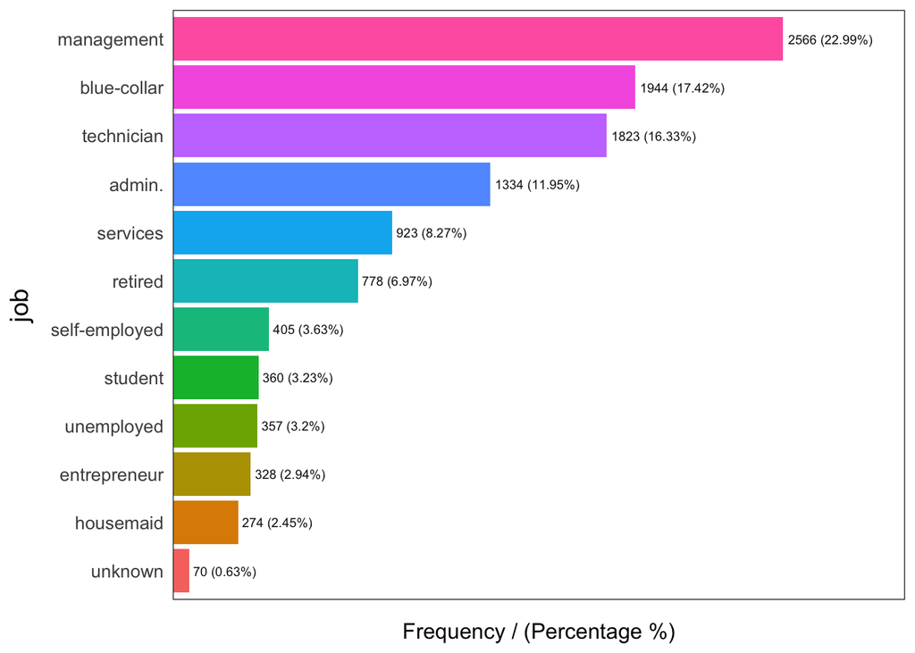

```
##              job frequency percentage cumulative_perc
## 1     management      2566      22.99              23
## 2    blue-collar      1944      17.42              40
## 3     technician      1823      16.33              57
## 4         admin.      1334      11.95              69
## 5       services       923       8.27              77
## 6        retired       778       6.97              84
## 7  self-employed       405       3.63              88
## 8        student       360       3.23              91
## 9     unemployed       357       3.20              94
## 10  entrepreneur       328       2.94              97
## 11     housemaid       274       2.45              99
## 12       unknown        70       0.63             100
```

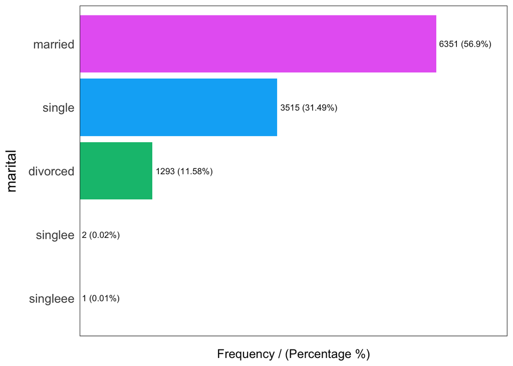

```
##    marital frequency percentage cumulative_perc
## 1  married      6351      56.90              57
## 2   single      3515      31.49              88
## 3 divorced      1293      11.58             100
## 4  singlee         2       0.02             100
## 5 singleee         1       0.01             100
```

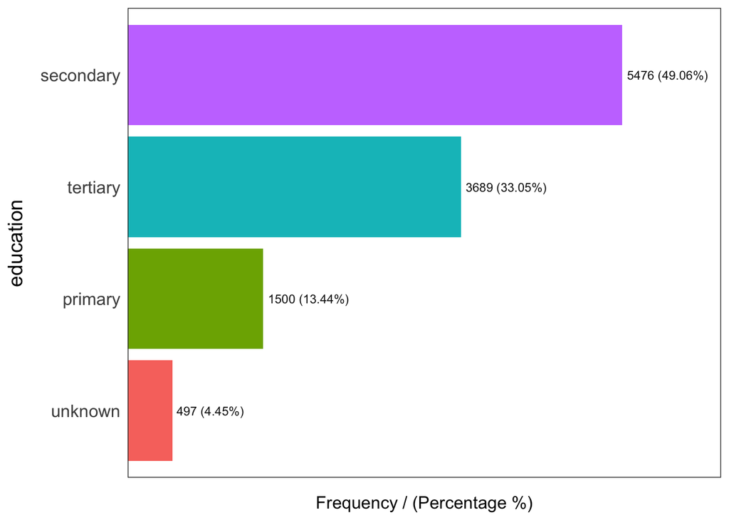

```
##   education frequency percentage cumulative_perc
## 1 secondary      5476       49.1              49
## 2  tertiary      3689       33.0              82
## 3   primary      1500       13.4              96
## 4   unknown       497        4.5             100
```

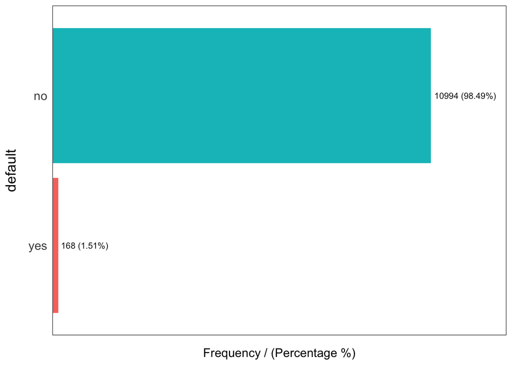

```
##   default frequency percentage cumulative_perc
## 1      no     10994       98.5              98
## 2     yes       168        1.5             100
```

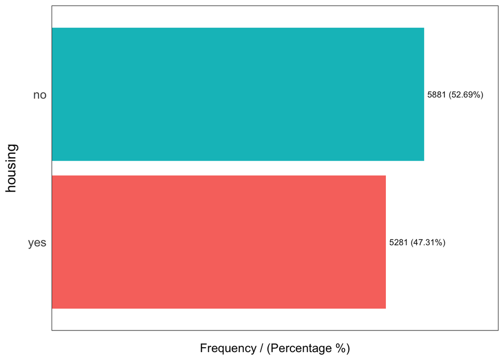

```
##   housing frequency percentage cumulative_perc
## 1      no      5881         53              53
## 2     yes      5281         47             100
```

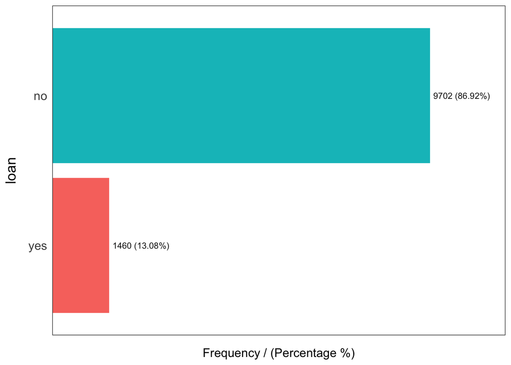

```
##   loan frequency percentage cumulative_perc
## 1   no      9702         87              87
## 2  yes      1460         13             100
```

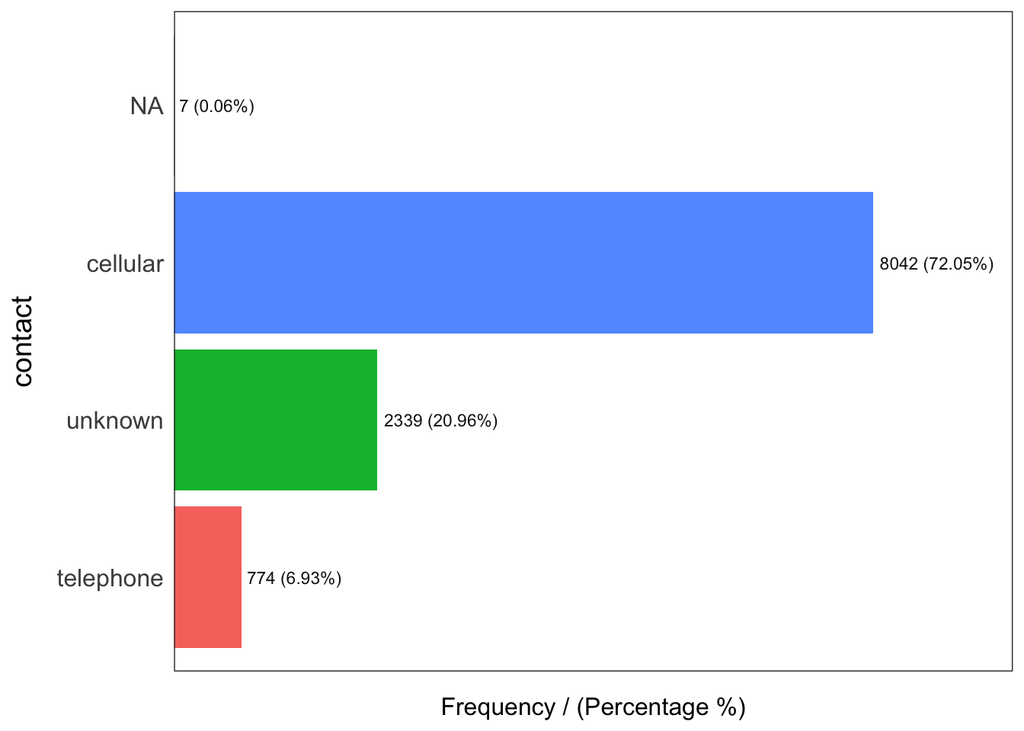

```
##     contact frequency percentage cumulative_perc
## 1  cellular      8042      72.05              72
## 2   unknown      2339      20.96              93
## 3 telephone       774       6.93             100
## 4      <NA>         7       0.06             100
```

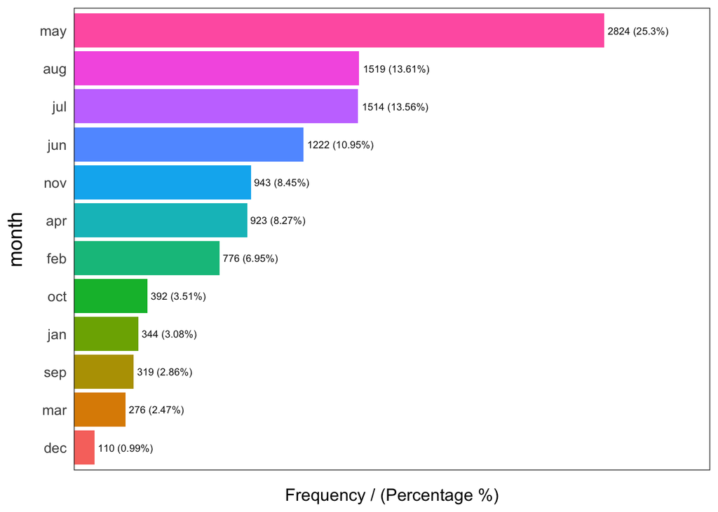

```
##    month frequency percentage cumulative_perc
## 1    may      2824      25.30              25
## 2    aug      1519      13.61              39
## 3    jul      1514      13.56              52
## 4    jun      1222      10.95              63
## 5    nov       943       8.45              72
## 6    apr       923       8.27              80
## 7    feb       776       6.95              87
## 8    oct       392       3.51              91
## 9    jan       344       3.08              94
## 10   sep       319       2.86              97
## 11   mar       276       2.47              99
## 12   dec       110       0.99             100
```

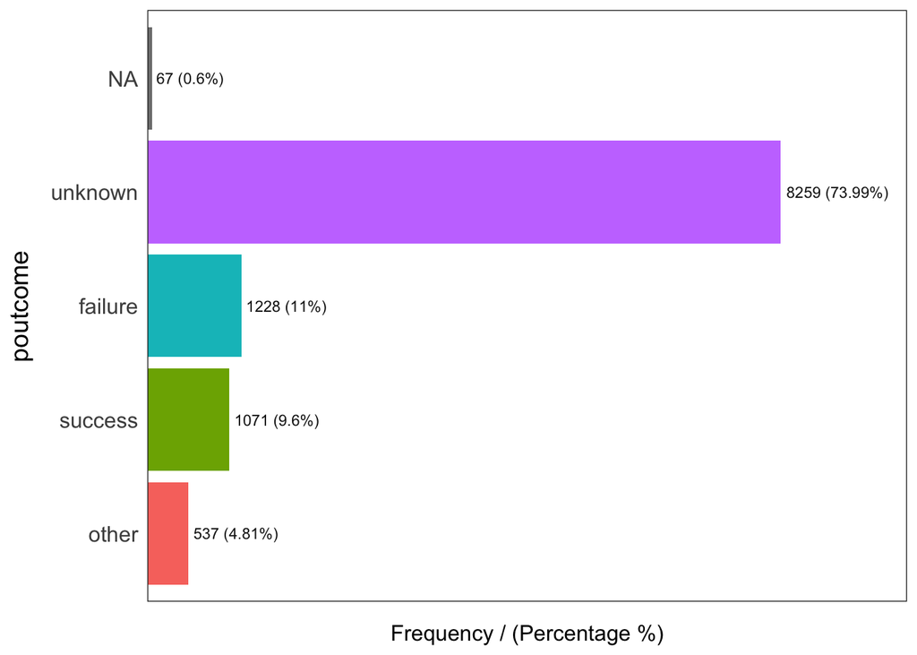

```
##   poutcome frequency percentage cumulative_perc
## 1  unknown      8259       74.0              74
## 2  failure      1228       11.0              85
## 3  success      1071        9.6              95
## 4    other       537        4.8              99
## 5     <NA>        67        0.6             100
```

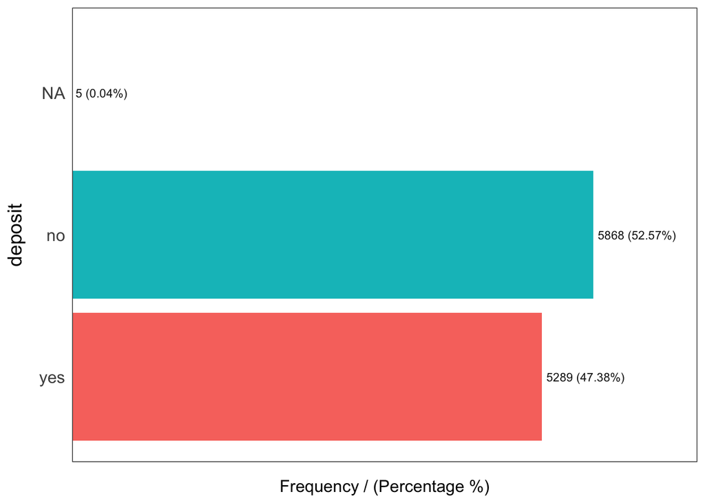

```
##   deposit frequency percentage cumulative_perc
## 1      no      5868      52.57              53
## 2     yes      5289      47.38             100
## 3    <NA>         5       0.04             100
```

```
## [1] "Variables processed: job, marital, education, default, housing, loan, contact, month, poutcome, deposit"
```

```r
freq(data_bank)
```

```r
# RTA 1: `deposit` tiene nulos, y deben excluirse los casos.
# RTA 2: LA variable `marital` tiene 3 valores que representan lo mismo (single, singlee, singleee)
```

5 - ¿Cuál es el rango de ‘age’ en donde se concentran el 80% de los datos?

```r
profiling_num(data_bank$age)
```

```
##   variable mean std_dev variation_coef p_01 p_05 p_25 p_50 p_75 p_95 p_99
## 1      var   43     211            4.9   22   26   32   39   49   61   77
##   skewness kurtosis iqr range_98 range_80
## 1      105    11088  17 [22, 77] [28, 58]
```

```r
# RTA: [28, 58] (métrica: range_80)
```

6 - Remover los valores extremos de la variable age asignandole el percentil 98 a todo lo que le supere.

6a - Calcular percentil 98

```r
p98=quantile(data_bank$age, probs =  0.98)
```

6b - Obtener el vector flag (TRUE/FALSE) de todo lo que lo supere

```r
v_flag_percentil=data_bank$age>p98
```

6c - Asignar el valor de 6a), y verificar la distribución de nuevo

```r
data_bank$age[v_flag_percentil]=p98
summary(data_bank$age)
```

```
##    Min. 1st Qu.  Median    Mean 3rd Qu.    Max.
##       2      32      39      41      49      72
```